# Homework 2

# Question 1

```r
set.seed(43202)
n <- 100
p <- 20
repetitions <- 200

################################################################################
#############  Generate one covariate matrix, then keep it fixed.  #############
################################################################################

# mu is the theoretical true value, which cannot be measured without error.
# And we assume that the 20 variables are its real predictor
X_all <- matrix(rnorm(n * p), nrow = n, ncol = p)
beta <- 0.4^sqrt(1:p)
mu <- drop(X_all %*% beta)

# Rows are repetitions; columns are predictor counts 0 through p.
train_mse <- test_mse <- matrix(NA_real_, nrow = repetitions, ncol = p + 1)

# Each run observes a fresh training and test response.
for (k in seq_len(repetitions)) {

  # y_train and y_test is the measured response var,
  # it is computed with mu + some random noise
  y_train <- mu + rnorm(n)
  y_test <- mu + rnorm(n)

  # Compare every candidate model on this same response pair.
  for (m in 0:p) {
    X_m <- cbind(1, X_all[, seq_len(m), drop = FALSE])
    Q <- qr.Q(qr(X_m))
    y_hat <- drop(Q %*% crossprod(Q, y_train))

    train_mse[k, m + 1] <- mean((y_train - y_hat)^2)
    test_mse[k, m + 1] <- mean((y_test - y_hat)^2)
  }
}

theory_train <- theory_test <- numeric(p + 1)

# Fit the true mean to calculate the fixed-design approximation bias.
for (m in 0:p) {
  X_m <- cbind(1, X_all[, seq_len(m), drop = FALSE])
  Q <- qr.Q(qr(X_m))
  projected_mu <- Q %*% crossprod(Q, mu)
  bias_mse <- mean((mu - projected_mu)^2)
  # We use the formula derived in the lecture in the following formula.
  # Sigma2 is 1.
  theory_train[m + 1] <- bias_mse + 1 - (m + 1) / n
  theory_test[m + 1] <- bias_mse + 1 + (m + 1) / n
}
```

## 1a

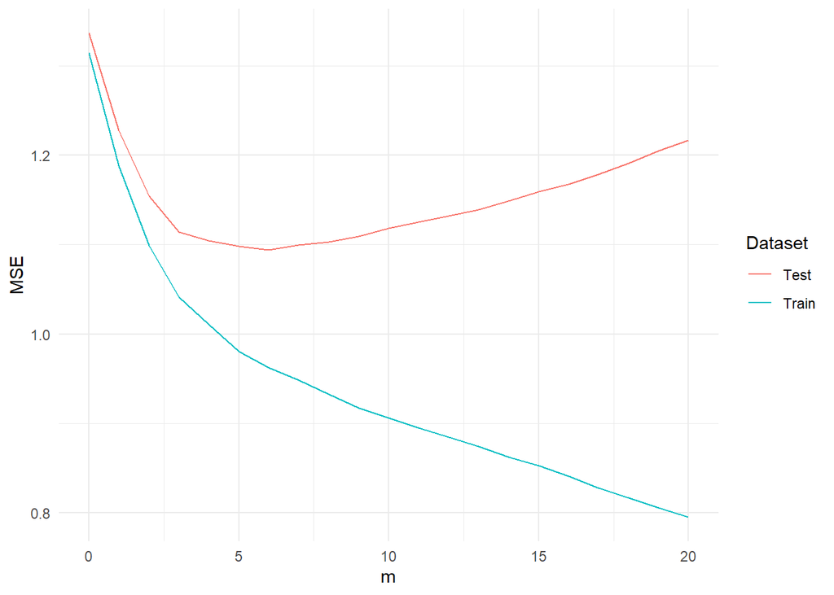

```r
results_r <- data.frame(
  m = 0:p,
  train = colMeans(train_mse),
  test = colMeans(test_mse)
)

library(ggplot2)

ggplot(results_r, aes(x = m)) +
  geom_line(aes(y = train, color = "Train")) +
  geom_line(aes(y = test, color = "Test")) +
  labs(x = "m", y = "MSE", color = "Dataset") +
  theme_minimal()
```

```r
mono_dec_check <-
  sapply(2:21, FUN = function(X) results_r$train[X] <= results_r$train[X-1])
if (all(mono_dec_check)) print("Train_mse is monotonicly decreasing")
```

```
[1] "Train_mse is monotonicly decreasing"
```

## 1b

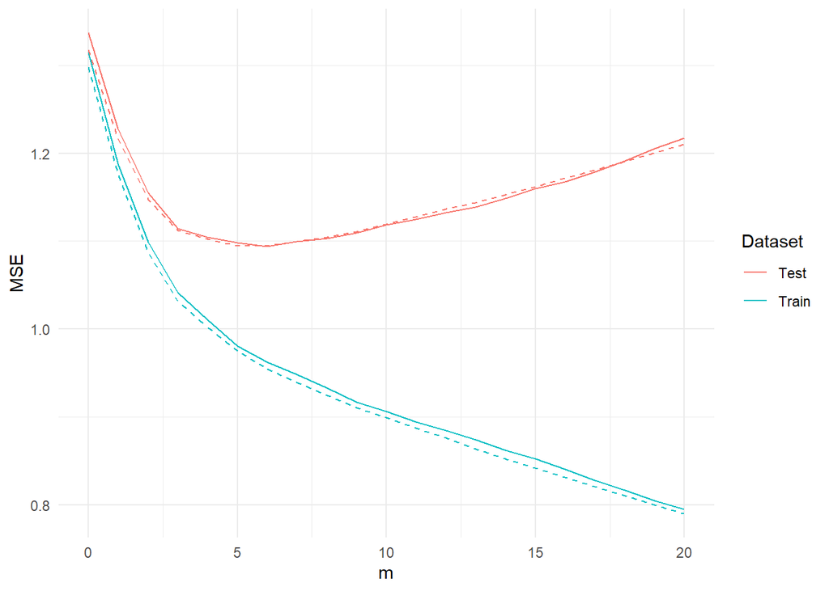

```r
results_r <- data.frame(
  m = 0:p,
  train = colMeans(train_mse),
  theory_train = theory_train,
  test = colMeans(test_mse),
  theory_test = theory_test
)

ggplot(results_r, aes(x = m)) +
  geom_line(aes(y = train, color = "Train")) +
  geom_line(aes(y = test, color = "Test")) +
  geom_line(aes(y = theory_train, color = "Train"), linetype = "dashed") +
  geom_line(aes(y = theory_test, color = "Test"), linetype = "dashed") +
  labs(x = "m", y = "MSE", color = "Dataset") +
  theme_minimal()
```

## 1c

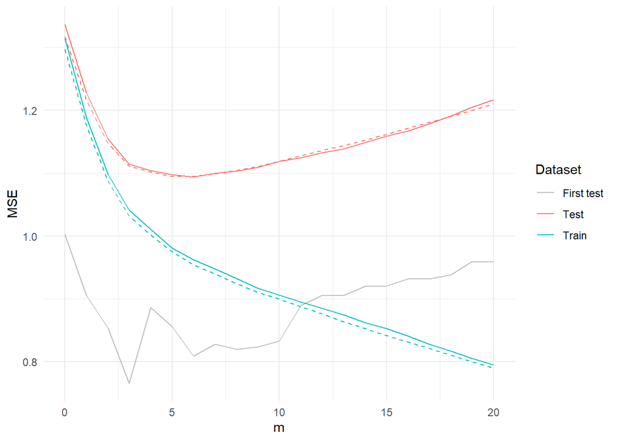

```r
results_r <- data.frame(
  m = 0:p,
  train = colMeans(train_mse),
  theory_train = theory_train,
  test = colMeans(test_mse),
  theory_test = theory_test,
  first_test = test_mse[1, ]
)

ggplot(results_r, aes(x = m)) +
  geom_line(aes(y = first_test, color = "First test")) +
  geom_line(aes(y = train, color = "Train")) +
  geom_line(aes(y = test, color = "Test")) +
  geom_line(aes(y = theory_train, color = "Train"), linetype = "dashed") +
  geom_line(aes(y = theory_test, color = "Test"), linetype = "dashed") +
  scale_color_manual(values = c("Train" = "#00BFC4",
  "Test" = "#F8766D", "First test" = "grey")) +
  labs(x = "m", y = "MSE", color = "Dataset") +
  theme_minimal()
```

The line representing the first test MSE is not as smooth as the average test MSE because of the randomness of the random error. The 200 iteration cancel out the effect of the random error. Therefore, it is much smoother.

While it is true that the bias will decrease as more parameters enter the model, the variance for the test MSE will actually be inflated. This can be seen clearly in test MSE’s formula. As p goes up, test MSE also goes up. On the contrary, train MSE’s formula states that as p goes up, the MSE will go down.

# Question 2

```r
set.seed(43203)
n <- 100
p <- 6
sigma2 <- 1
repetitions <- 200

X_all <- outer(
  1:n, 1:p,
  function(i, j) sqrt(2) * cos(pi * j * (i - 0.5) / n)
) # Full design matrix

beta <- rep(0.5, p) # Real coefficients for parameter
x0 <- c(0, 1, 0, 0, 1, 0) # Hypothetical case of combination of predictors
mu <- drop(X_all %*% beta) # Real response variable from cases in X_all
mu0 <- sum(x0 * beta) # Real response variable from case of X0
theoretical <- numeric(p + 1)
```

## 2a

```r
###############################################################################
####################### Compute expected square bias  #######################
###############################################################################

# Compute the target-specific expectations separately.
for (m in 0:p) {
  omitted <- if (m < p) (m + 1):p else integer(0)  # The parameters we want to discard
  omitted_signal <- sum(x0[omitted] * beta[omitted]) # First term of the equation
  estimation_variance <- sigma2 * (1 + sum(x0[seq_len(m)]^2)) / n # Second term
  theoretical[m + 1] <- omitted_signal^2 + estimation_variance
}
```

Explaining it in a intuitive sense. The variace term comes from the randomness of the random error. This causes the beta hat that we fitted to deviate from the real unobservable beta. This will cause our prediction deviating from the real value. On the other hand, the predictors from m to p is actually involved in the creation of true response variable. It is thus present in its equation. Its absense in the prediction of mu_0.m also causes mu_0.m to deviate from mu_0.p.

The expected squared error changes at m=2 and m=5 and stays unchanged when m = 1, 3, 4, 6. The explanation will be given in question c

## 2b

```r
###############################################################################
################ Simulate mu0_hat at different m and compute mse ##############
###############################################################################
simulation_error <- matrix(NA_real_, nrow = repetitions, ncol = p + 1)

# Each run observes a fresh response.
for (k in seq_len(repetitions)) {
  y_train <- mu + rnorm(n)

  # Compare every candidate model on this same response.
  for (m in 0:p) {
    X_m <- cbind(1, X_all[, seq_len(m), drop = FALSE]) # Design matrix with m predictor
    # From beta_hat = (Xt(X))-1t(X)y
    beta_hat <- solve(crossprod(X_m), crossprod(X_m, y_train))
    target_row <- c(1, x0[seq_len(m)]) # x0+1
    mu0_hat <- drop(target_row %*% beta_hat) # Use [1, x0] and beta hat to fit mu_0 hat
    simulation_error[k, m + 1] <- (mu0_hat - mu0)^2
  }
}
simulated <- colMeans(simulation_error)

target_results_r <- data.frame(
  m = 0:p,
  simulated = simulated,
  theoretical = theoretical
)
print(target_results_r, digits = 4)
```

```
  m simulated theoretical
1 0   1.01892        1.01
2 1   1.01892        1.01
3 2   0.26712        0.27
4 3   0.26712        0.27
5 4   0.26712        0.27
6 5   0.03376        0.03
7 6   0.03376        0.03
```

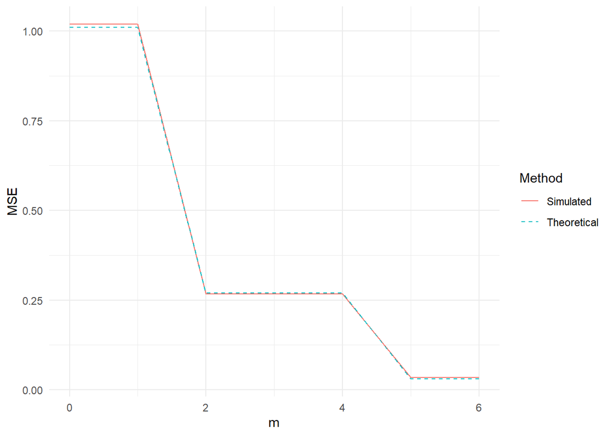

```r
ggplot(target_results_r, aes(x = m)) +
  geom_line(aes(y = simulated, color = "Simulated")) +
  geom_line(aes(y = theoretical, color = "Theoretical"), linetype = "dashed") +
  labs(x = "m", y = "MSE", color = "Method") +
  theme_minimal()
```

## 2c

Only the second and the fifth predictor contribute to the mean of mu_0.m because only the second and the fifth entry of the x0 vector is non-zero. As a result, no matter how the coefficients for other predictors change, the value of mu_0.m only when predictor 2 and 5 enter the model.

# Question 3

## 3b

The expected optimism is

This ordering need not hold for every realized pair of responses because the training and test MSEs contain random error terms. Consequently, for some particular responses, the realized test MSE may be smaller than the realized training MSE, even though the inequality holds in expectation.

## 3c

Here $p=5$ denotes the number of predictors, so the fitted parameter count, including the intercept, is $p+1=6$. Using $n=120$, $\operatorname{RSS}=116.4$, and $\widehat{\sigma}^2=0.96$, the corrected estimate of the test MSE is

$$\begin{aligned}
\widehat{\operatorname{MSE}}_{\mathrm{test}}
&=\frac{\operatorname{RSS}+2(p+1)\widehat{\sigma}^2}{n}\\
&=\frac{116.4+2(6)(0.96)}{120}\\
&=\frac{127.92}{120}=1.066.
\end{aligned}$$

Mallows’ $C_p$ is

$$\begin{aligned}
C_p
&=\frac{\operatorname{RSS}}{\widehat{\sigma}^2}-n+2(p+1)\\
&=\frac{116.4}{0.96}-120+2(6)\\
&=121.25-120+12=13.25.
\end{aligned}$$

The two quantities are related by

$$\begin{aligned}
C_p
&=\frac{\operatorname{RSS}}{\widehat{\sigma}^2}-n+2(p+1)\\
&=\frac{\operatorname{RSS}+2(p+1)\widehat{\sigma}^2-n\widehat{\sigma}^2}
{\widehat{\sigma}^2}\\
&=\frac{n\widehat{\operatorname{MSE}}_{\mathrm{test}}}
{\widehat{\sigma}^2}-n,
\end{aligned}$$

or, equivalently,

$$\widehat{\operatorname{MSE}}_{\mathrm{test}}
=\widehat{\sigma}^2\left(1+\frac{C_p}{n}\right).$$

Therefore, when $n$ and $\widehat{\sigma}^2$ are common to all candidate models, the corrected test MSE is an increasing affine transformation of $C_p$. Minimizing one criterion is consequently equivalent to minimizing the other.

# Question 4

```r
library(tidyverse)
q4_df <- read_csv("data/diabetes.csv")
n <- 370

Model.A_dat <- q4_df[1:n, c("y", "bmi", "bp", "s5", "sex", "s1", "s2", "s4")]
Model.B_dat <- q4_df[1:n, c("y", "s6", "bmi", "bp", "s5", "sex", "s1", "s2", "s4")]
Model.F_dat <- q4_df[1:n,]

Model.A_p <- ncol(Model.A_dat) - 1
Model.B_p <- ncol(Model.B_dat) - 1
Model.F_p <- ncol(Model.F_dat) - 1

Model.A_res <- lm(y ~ ., data = Model.A_dat)
Model.B_res <- lm(y ~ ., data = Model.B_dat)
Model.F_res <- lm(y ~ ., data = Model.F_dat)

Model.A_RSS <- sum(Model.A_res$residuals^2)
Model.B_RSS <- sum(Model.B_res$residuals^2)
Model.F_RSS <- sum(Model.F_res$residuals^2)

common_noise_var <- Model.F_RSS/(n - Model.F_p - 1)

Model.A_Cp <- Model.A_RSS/common_noise_var - n + 2 * (Model.A_p + 1)
Model.B_Cp <- Model.B_RSS/common_noise_var - n + 2 * (Model.B_p + 1)
Model.A_AIC <- n * log(Model.A_RSS / n) + 2 * (Model.A_p + 1)
Model.B_AIC <- n * log(Model.B_RSS / n) + 2 * (Model.B_p + 1)
Model.A_BIC <- n * log(Model.A_RSS / n) + (Model.A_p + 1) * log(n)
Model.B_BIC <- n * log(Model.B_RSS / n) + (Model.B_p + 1) * log(n)
```

## 4a

```r
q4a_rowname <- c("Model A", "Model B", "Model Full")

q4a <- data.frame(
  p = c(Model.A_p,Model.B_p,Model.F_p),
  RSS = c(Model.A_RSS,Model.B_RSS,Model.F_RSS),
  Resid_df = c(NA, NA, n - (Model.F_p + 1)),
  "common_noise_var" = c(NA, NA, common_noise_var)
)
rownames(q4a) <- q4a_rowname
q4a
```

```
            p     RSS Resid_df common_noise_var
Model A     7 1098909       NA               NA
Model B     8 1089717       NA               NA
Model Full 10 1089452      359         3034.684
```

## 4b

```r
q4b_rowname <- c("Model A", "Model B")
q4b <- data.frame(
  Cp = c(Model.A_Cp,Model.B_Cp),
  AIC = c(Model.A_AIC,Model.B_AIC),
  BIC = c(Model.A_BIC,Model.B_BIC)
)
rownames(q4b) <- q4b_rowname

q4b
```

```
              Cp      AIC      BIC
Model A 8.116253 2974.640 3005.948
Model B 7.087434 2973.532 3008.754
```

For all these three criteria, the lower value indicate a better model. It can be observed from the table that model B is lower at Cp and AIC value. On the other hand, Model A has a lower BIC value.

## 4c

```r
s6.fit.impro_Cp <- (Model.A_RSS - Model.B_RSS) / common_noise_var
s6.fit.impro_AIC.BIC <- n * (log(Model.A_RSS) - log(Model.B_RSS))
penalty_Cp <- 2
penalty_AIC <- 2
penalty_BIC <- log(n) * 1

c("Cp_fit_improvement" = s6.fit.impro_Cp, "AIC, BIC fit improvement" = s6.fit.impro_AIC.BIC, "penalty_Cp" = penalty_Cp, "penalty_AIC" = penalty_AIC, "penalty_BIC" = penalty_BIC)
```

```
      Cp_fit_improvement AIC, BIC fit improvement               penalty_Cp
                3.028819                 3.107775                 2.000000
             penalty_AIC              penalty_BIC
                2.000000                 5.913503
```

The penalty for Cp and AIC for having an extra predictor is 2. BIC typically has a harsher penalty, in this case at 5.9135. The fit improvement at all three cases are slightly above 3. To sum up, in the case of Cp and AIC, the improvement of including s6 outweight the penalty. This finding is aligned with the fact that AIC and Cp favors model B. On the other hand, the penalty imposed by BIC is greater than that of the fit improvement, causing it to favor model A instead.

When we select the model, the goal is to minimize testing MSE. As a result, we need to balance between variance and bias. Data generating model typically include many variables. It might help us decrease the bias effectively, however, the variance term will be inflated. At the end of the day, we might not get the minimum test MSE.

# Question 5

## 5a

The minimum of the 11 test MSE values often under-estimate the future prediction error of that model. The test MSE of a model can be small simply by chance. For instance, in question 1, the test MSE of test 1 is smaller than the average at with every number of predictors (m = 1, 2, …, 20). If we simply use test 1’s MSE as future prediction error, we will underestimate future prediction error.

## 5b

1. Divide the training data into five equal portions
2. Fit the model using four of the five portions of the training data and compute the MSE using the other portion. Keep doing this until every portion has been used to calculate the MSE. Do this for all 11 candidate models. A total of 55 models should be fitted. Calculate the average test MSE (average the 5 test MSE) for all 11 candidate models (you should have 11 average MSE).
3. Select the model with the smallest average MSE. That is the subset of the predictors we want in our final model.
4. Use the subset of the predictor and fit the model on the entire training data to get the coefficients.
5. Calculate test MSE using the subset of the predictors and coefficients on the testing data to evaluate the model.